# M2.991_20241_PAC1-Enunciat-1

[figure not shown]

M2.991 · Aprenentatge automàtic · PAC1

2024-1 · Màster universitari en Ciència de dades (Data science)

Estudis d'Informàtica, Multimèdia i Telecomunicació

PAC 1: Preparació de dades

L'objectiu principal d'aquesta primera PAC és que us familiaritzeu amb l'entorn de treball que utilitzareu en la resta de pràctiques de l'assignatura. Aquest entorn estarà format per un conjunt de dependències relatives a certs mòduls de Python que seran necessaris per poder executar la vostra PAC de manera correcta. Aquestes dependències les gestionarem gràcies a l'ajuda d'Anaconda. Una altra de les eines fonamentals del que serà el vostre nou entorn de treball serà Jupyter, que us permetrà treballar amb Notebooks (fitxers *.ipynb) com el present enunciat.

Un altre dels aspectes més importants que cobrirem en aquesta primera PAC, tal com indica el títol, és el de la preparació de les dades. En aquesta PAC aprendrem a carregar un conjunt de dades o *dataset* i ens ajudarem d'eines de visualització per comprendre millor com es distribueixen les dades amb l'objectiu d'entendre com podem treure'n profit. A més, ens acostumarem a treballar amb conjunts d'entrenament i de prova per confirmar si les conclusions que traiem sobre una part de les mostres es poden generalitzar i extrapolar a la resta.

En resum, en aquesta pràctica veurem com aplicar diferents tècniques per a la càrrega i preparació de dades seguint els passos llistats a continuació:

1. Càrrega d'un conjunt de dades (1 punt)
2. Anàlisi de les dades (2.5 punts)  
   2.1. Anàlisi estadístic bàsic  
   2.2. Anàlisi exploratori de les dades
3. Preprocessament de les dades (1.5 punts)
4. Reducció de la dimensionalitat (2.5 punts)
5. Conjunts desbalancejats de dades (2.5 punts)  
   5.1. *Oversampling*

**Important:** cada un dels exercicis pot suposar diversos minuts d'execució, per la qual cosa l'entrega s'ha de fer en format notebook i en format html, on es vegi el codi, els resultats i comentaris de cada exercici. Es pot exportar el notebook a html des del menú File $\to$ Download as $\to$ HTML.

**Important:** existeix un tipus de cel·la especial per a albergar text. Aquest tipus de cel·la us serà molt útil per respondre a les diferents preguntes teòriques plantejades al llarg de cada PAC. Per canviar el tipus de cel·la a aquest tipus, escolliu en el menú: Cell $\to$ Cell Type $\to$ Markdown.

**Important:** la solució plantejada no ha d'utilitzar mètodes, funcions o paràmetres declarats "deprecated" en futures versions.

**Important:** no oblideu posar el vostre nom i cognoms a la següent cel·la.

**Nom i cognoms: Albert Lozano Valverde**

Per la realització de la pràctica, necessitarem importar els següents mòduls:

```python
import numpy as np
import pandas as pd
from sklearn import preprocessing
from sklearn.manifold import TSNE
from sklearn.decomposition import PCA
from sklearn.model_selection import train_test_split
from imblearn.over_sampling import RandomOverSampler, SMOTE, ADASYN

import matplotlib
import matplotlib.pyplot as plt

pd.set_option('display.max_columns', None)
seed = 100

%matplotlib inline
```

# Càrrega del conjunt de dades (1 punt)

Al llarg de tota la PAC treballarem amb el conjunt de dades anomenat *Bank Marketing*, que és un dels *datasets* disponibles al [Repositori d'Aprenentatge Automàtic de la Universitat de Califòrnia a Irvine](https://archive.ics.uci.edu/).

A l'enllaç [https://archive.ics.uci.edu/dataset/222/bank+marketing] teniu disponible tant el conjunt de dades *Bank Marketing* esmentat com tota la informació rellevant necessària per comprendre millor amb quin tipus de dades treballarem. En resum, les dades d'aquest *dataset* estan relacionades amb campanyes de màrqueting directe (trucades telefòniques) d'una institució bancària portuguesa. L'objectiu que es busca en aquest conjunt de dades és predir si el client contractarà un dipòsit a termini o no (variable *y*).

En primer lloc, haureu de carregar al Notebook el conjunt de dades amb el qual treballarem durant la resta de la PAC. Per fer-ho, podeu descarregar-lo manualment des de l'enllaç referit prèviament, tot i que us aconsellem que instal·leu i utilitzeu el mòdul *ucimlrepo* tal com s'explica a la pàgina del *dataset*.

**Exercici:** carregueu el conjunt de dades "Bank Marketing" i mostreu:

- El nombre i els noms dels atributs descriptius (variables que podrien ser utilitzades per predir la variable objectiu "y").
- El nombre de files (mostres) del conjunt de dades.
- Verifiqueu si hi ha "missing values", i si és així, en quines columnes.

Suggeriment: si utilitzeu ucimlrepo, exploreu els atributs *metadata* i *variables* de l'objecte obtingut.

Suggeriment: separeu el conjunt de dades original en les variables "X" (atributs descriptius) i "y" (variable objectiu), tot i que potser us sigui útil en algun moment tenir-les també en un únic DataFrame combinat.

```python
##opcio 1
#from ucimlrepo import fetch_ucirepo

## fetch dataset
#bank_marketing = fetch_ucirepo(id=222)

# data (as pandas dataframes)
#X = bank_marketing.data.features
#y = bank_marketing.data.targets

#Carregar apartir de la api, carrega a dataframes
#opcio 2
bank_marketing=pd.read_csv('bank+marketing/bank/bank-full.csv',sep=";")

variables=bank_marketing.columns.values.tolist()[0:-1]
print("Tennim "+str(len(variables))+ " atributs i els aributs son: "+ ', '.join(variables)+"\n")
print("El nombre de files del conjunt de dades es "+ str(bank_marketing.shape[0]))
```

```
Tennim 16 atributs i els aributs son: age, job, marital, education, default, balance, housing, loan, contact, day, month, duration, campaign, pdays, previous, poutcome

El nombre de files del conjunt de dades es 45211
```

```python
if(bank_marketing.isnull().values.any()):
    print("Hi ha missing values i estan a les columnes en les que possa true")
    print(bank_marketing.isna().any())
else:
    print("No hi ha missing values")
```

```
No hi ha missing values
```

També podem mirar el document "bank-names.txt" on afirma que no hi ha missing vaules en concret diu "8. Missing Attribute Values: None"

**Pregunta:** El conjunt de dades proposat correspon a un problema d'aprenentatge automàtic supervisat o no?; Si és el cas, de quin tipus d'aprenentatge supervisat estaríem parlant?

És un problema supervisat de classificació, ja que volem dir si hem aconseguit o no una venda

# Anàlisi de les dades (2.5 punts)

En aquest apartat visualitzarem cadascuna de les columnes o *features* del conjunt de dades per comprendre millor quina distribució tenen.

## Anàlisi estadística bàsica

**Exercici:** realitzeu un anàlisi estadística bàsica:

- Variables categòriques:
- Calculeu la freqüència.
- Feu un gràfic de barres per cada variable.
- Variables numèriques:
- Calculeu estadístics descriptius bàsics: mitjana, mediana, desviació estàndard, ...
- Feu un histograma per a cada variable.

Suggeriment: podeu utilitzar la llibreria "pandas" i les seves funcions "describe" i "value_counts", així com les funcions "bar", "hist" i "hist2d" de *matplotlib*.

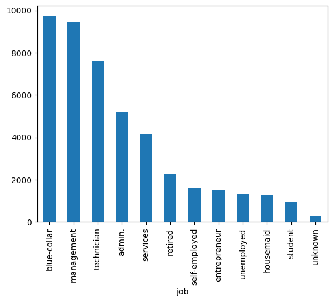

```python
bank_marketing["job"].value_counts().plot.bar()
plt.show()
```

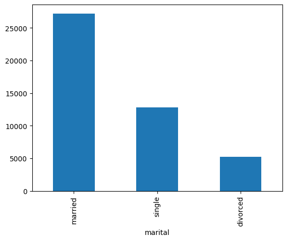

```python
bank_marketing["marital"].value_counts().plot.bar()
plt.show()
```

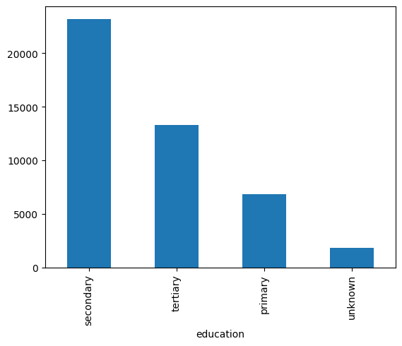

```python
bank_marketing["education"].value_counts().plot.bar()
plt.show()
```

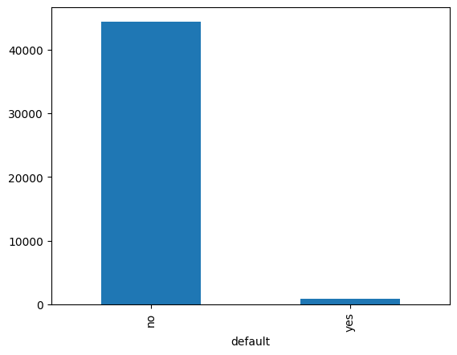

```python
bank_marketing["default"].value_counts().plot.bar()
plt.show()
```

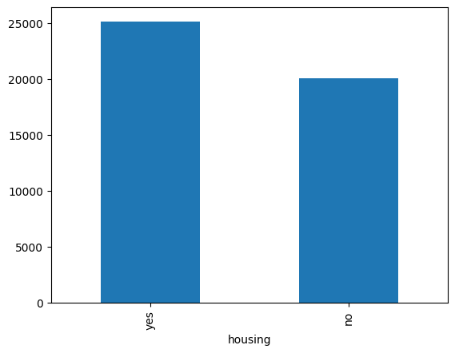

```python
bank_marketing["housing"].value_counts().plot.bar()
plt.show()
```

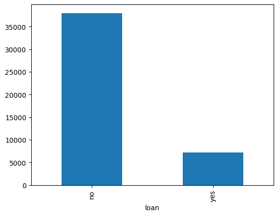

```python
bank_marketing["loan"].value_counts().plot.bar()
plt.show()
```

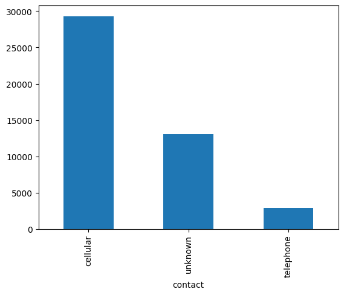

```python
bank_marketing["contact"].value_counts().plot.bar()
plt.show()
```

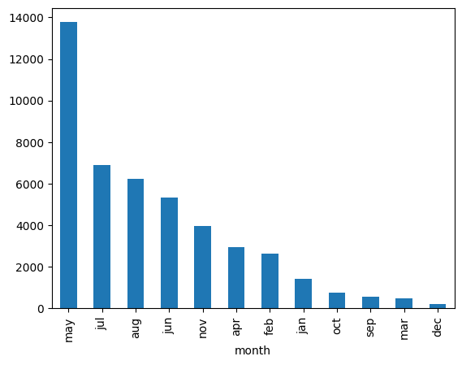

```python
bank_marketing["month"].value_counts().plot.bar()
plt.show()
```

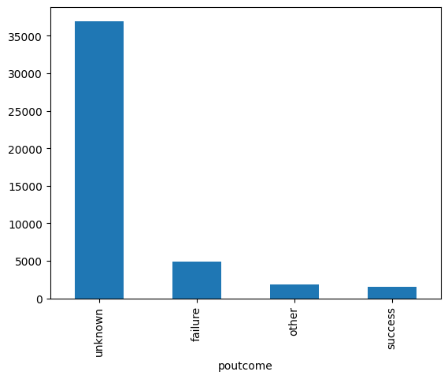

```python
bank_marketing["poutcome"].value_counts().plot.bar()
plt.show()
```

```python
bank_marketing.describe()
```

|  | age | balance | day | duration | campaign | pdays | previous |
| --- | --- | --- | --- | --- | --- | --- | --- |
| count | 45211.000000 | 45211.000000 | 45211.000000 | 45211.000000 | 45211.000000 | 45211.000000 | 45211.000000 |
| mean | 40.936210 | 1362.272058 | 15.806419 | 258.163080 | 2.763841 | 40.197828 | 0.580323 |
| std | 10.618762 | 3044.765829 | 8.322476 | 257.527812 | 3.098021 | 100.128746 | 2.303441 |
| min | 18.000000 | -8019.000000 | 1.000000 | 0.000000 | 1.000000 | -1.000000 | 0.000000 |
| 25% | 33.000000 | 72.000000 | 8.000000 | 103.000000 | 1.000000 | -1.000000 | 0.000000 |
| 50% | 39.000000 | 448.000000 | 16.000000 | 180.000000 | 2.000000 | -1.000000 | 0.000000 |
| 75% | 48.000000 | 1428.000000 | 21.000000 | 319.000000 | 3.000000 | -1.000000 | 0.000000 |
| max | 95.000000 | 102127.000000 | 31.000000 | 4918.000000 | 63.000000 | 871.000000 | 275.000000 |

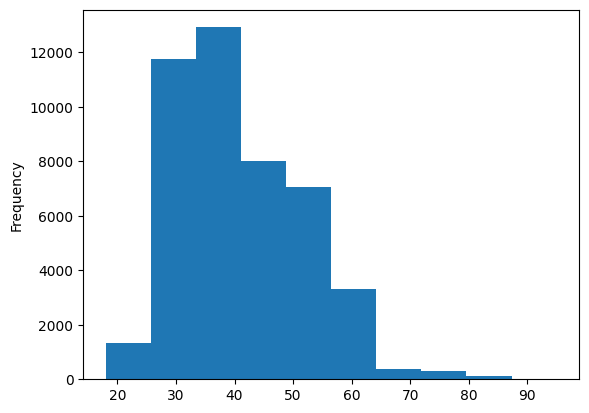

```python
bank_marketing["age"].plot.hist()
plt.show()
```

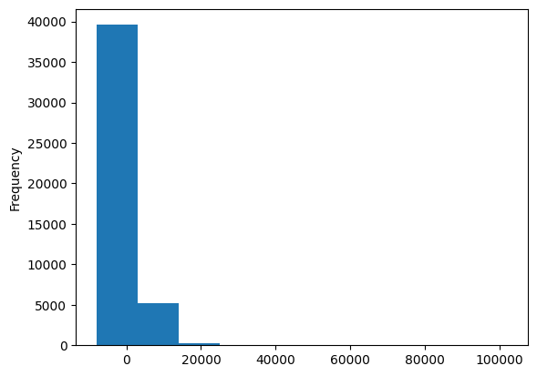

```python
bank_marketing["balance"].plot.hist()
plt.show()
```

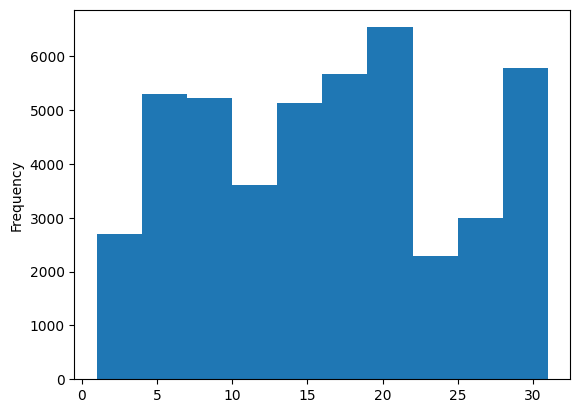

```python
bank_marketing["day"].plot.hist()
plt.show()
```

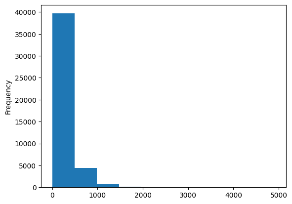

```python
bank_marketing["duration"].plot.hist()
plt.show()
```

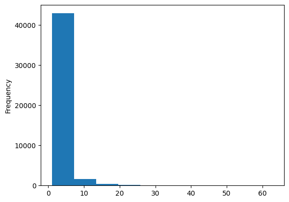

```python
bank_marketing["campaign"].plot.hist()
plt.show()
```

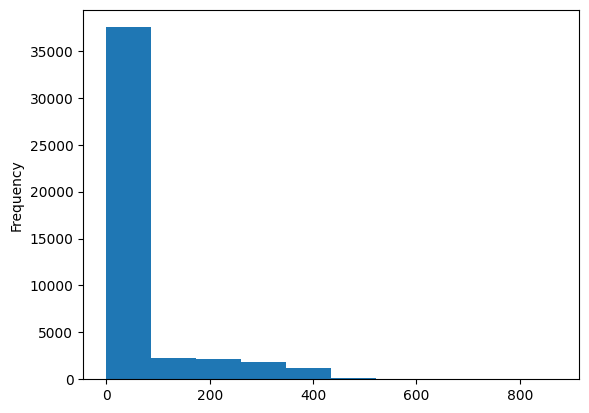

```python
bank_marketing["pdays"].plot.hist()
plt.show()
```

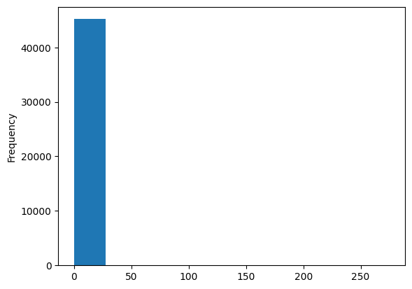

```python
bank_marketing["previous"].plot.hist()
plt.show()
```

**Anàlisi:** comenteu els resultats.

Coses rellevants, a la major part de la mostra no ha sigut contactada prèviament (variable previous amb el valor 75% més gran encara és 0) la majoria dels clients van tenir pocs contactes (campain té mitjana 2.763841) això fa pensar que la gent en pocs contactes decideix si vol o no vol contractar, fa pensar que els usuaris necessiten poques visites per decidir si volen o no volen el servei, per tant, seria interessant saber quin son els clients més probables per intentar parlar amb els perfils que siguin més probables que contractin.

## Anàlisi exploratòria de les dades

En aquest subapartat explorarem gràficament la relació dels atributs descriptius amb la variable objectiu i analitzarem les diferents correlacions.

**Exercici:** utilitzant una llibreria gràfica, com ara *matplotlib*, per a cadascuna de les variables categòriques, superposeu en un mateix gràfic el diagrama de barres per a cada valor possible de la variable objectiu, diferenciant amb un color diferent segons el valor de "y", és a dir, quan sigui "no" o quan sigui "yes". Afegiu una llegenda per saber a quina classe correspon cada histograma.

La finalitat és observar com es distribueix cadascun dels atributs en funció de la classe que tenen, per poder identificar de manera visual i ràpida si alguns atributs ens permeten predir millor que altres el valor de la variable objectiu.

Suggeriment: podeu utilitzar el paràmetre "alpha" en els gràfics perquè es puguin apreciar els dos histogrames.

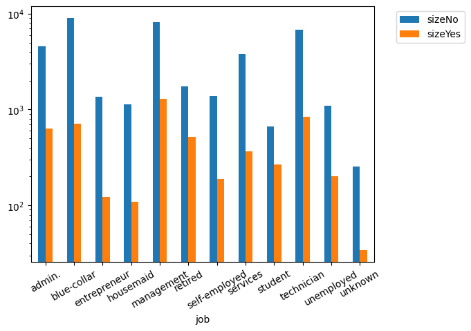

```python
total=bank_marketing.groupby(by=["y", "job"], as_index=False).size()
no=total[total["y"]=="no"][["job","size"]]
yes=total[total["y"]=="yes"][["job","size"]]
df=pd.merge(no,yes,on="job",suffixes=["No","Yes"])
ax = df.plot(kind='bar', x='job', logy=True, rot=0)
ax.legend(bbox_to_anchor=(1.05, 1), loc='upper left')
plt.xticks(rotation=30)
plt.show()
```

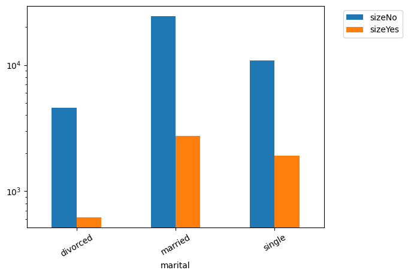

```python
total=bank_marketing.groupby(by=["y", "marital"], as_index=False).size()
no=total[total["y"]=="no"][["marital","size"]]
yes=total[total["y"]=="yes"][["marital","size"]]
df=pd.merge(no,yes,on="marital",suffixes=["No","Yes"])
ax = df.plot(kind='bar', x='marital', logy=True, rot=0)
ax.legend(bbox_to_anchor=(1.05, 1), loc='upper left')
plt.xticks(rotation=30)
plt.show()
```

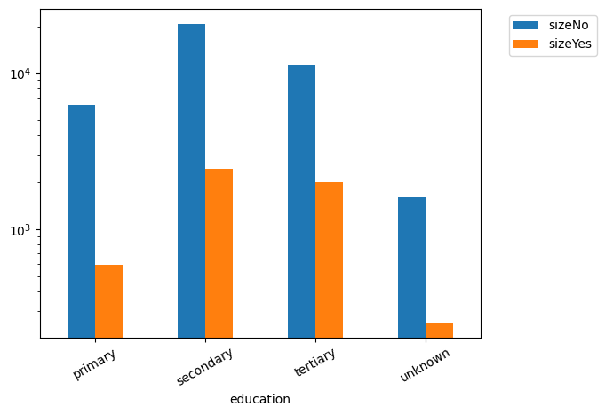

```python
total=bank_marketing.groupby(by=["y", "education"], as_index=False).size()
no=total[total["y"]=="no"][["education","size"]]
yes=total[total["y"]=="yes"][["education","size"]]
df=pd.merge(no,yes,on="education",suffixes=["No","Yes"])
ax = df.plot(kind='bar', x='education', logy=True, rot=0)
ax.legend(bbox_to_anchor=(1.05, 1), loc='upper left')
plt.xticks(rotation=30)
plt.show()
```

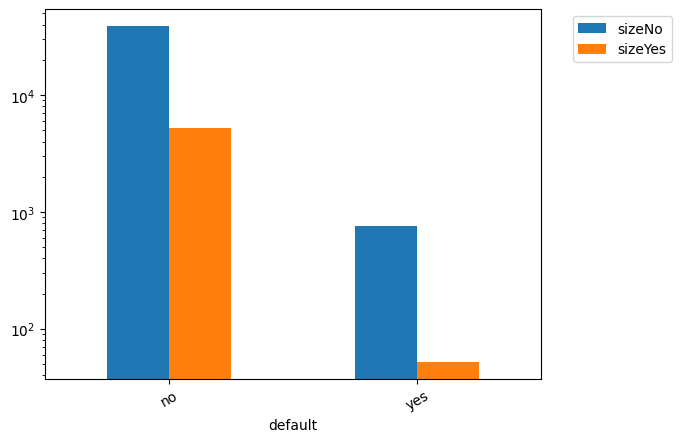

```python
total=bank_marketing.groupby(by=["y", "default"], as_index=False).size()
no=total[total["y"]=="no"][["default","size"]]
yes=total[total["y"]=="yes"][["default","size"]]
df=pd.merge(no,yes,on="default",suffixes=["No","Yes"])
ax = df.plot(kind='bar', x='default', logy=True, rot=0)
ax.legend(bbox_to_anchor=(1.05, 1), loc='upper left')
plt.xticks(rotation=30)
plt.show()
```

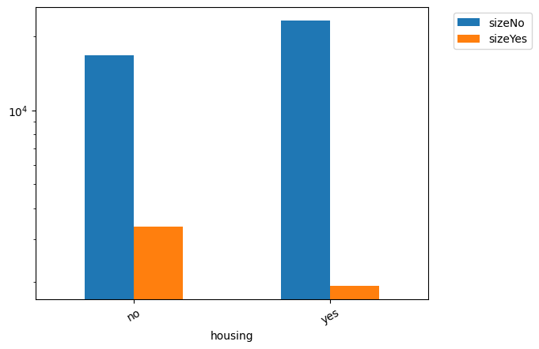

```python
total=bank_marketing.groupby(by=["y", "housing"], as_index=False).size()
no=total[total["y"]=="no"][["housing","size"]]
yes=total[total["y"]=="yes"][["housing","size"]]
df=pd.merge(no,yes,on="housing",suffixes=["No","Yes"])
ax = df.plot(kind='bar', x='housing', logy=True, rot=0)
ax.legend(bbox_to_anchor=(1.05, 1), loc='upper left')
plt.xticks(rotation=30)
plt.show()
```

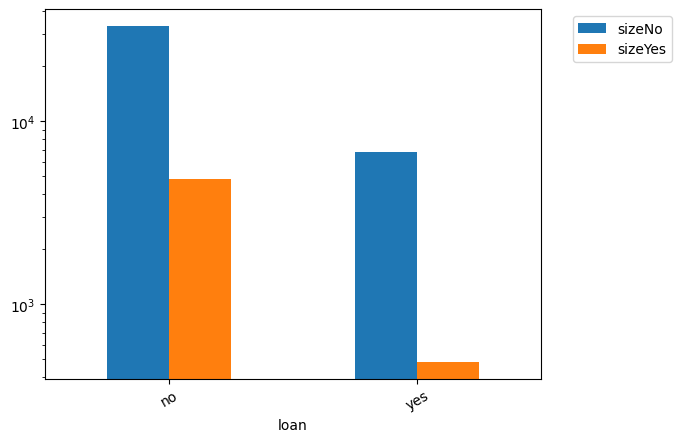

```python
total=bank_marketing.groupby(by=["y", "loan"], as_index=False).size()
no=total[total["y"]=="no"][["loan","size"]]
yes=total[total["y"]=="yes"][["loan","size"]]
df=pd.merge(no,yes,on="loan",suffixes=["No","Yes"])
ax = df.plot(kind='bar', x='loan', logy=True, rot=0)
ax.legend(bbox_to_anchor=(1.05, 1), loc='upper left')
plt.xticks(rotation=30)
plt.show()
```

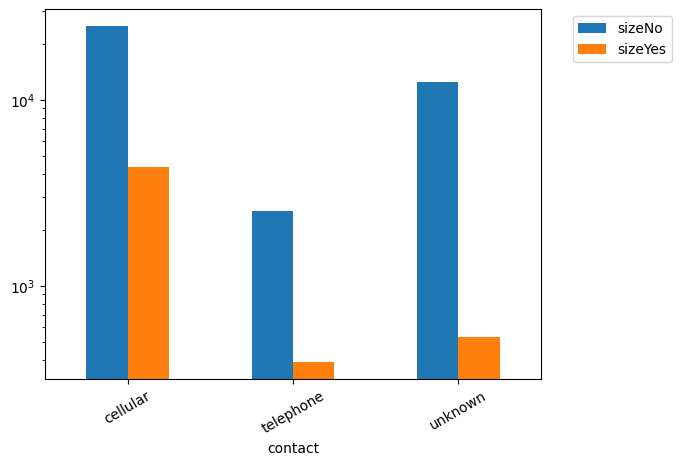

```python
total=bank_marketing.groupby(by=["y", "contact"], as_index=False).size()
no=total[total["y"]=="no"][["contact","size"]]
yes=total[total["y"]=="yes"][["contact","size"]]
df=pd.merge(no,yes,on="contact",suffixes=["No","Yes"])
ax = df.plot(kind='bar', x='contact', logy=True, rot=0)
ax.legend(bbox_to_anchor=(1.05, 1), loc='upper left')
plt.xticks(rotation=30)
plt.show()
```

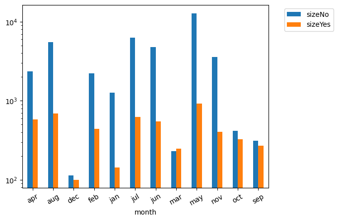

```python
total=bank_marketing.groupby(by=["y", "month"], as_index=False).size()
no=total[total["y"]=="no"][["month","size"]]
yes=total[total["y"]=="yes"][["month","size"]]
df=pd.merge(no,yes,on="month",suffixes=["No","Yes"])
ax = df.plot(kind='bar', x='month', logy=True, rot=0)
ax.legend(bbox_to_anchor=(1.05, 1), loc='upper left')
plt.xticks(rotation=30)
plt.show()
```

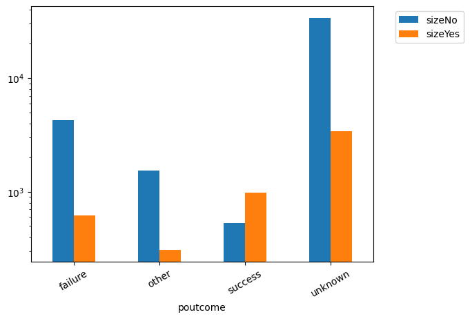

```python
total=bank_marketing.groupby(by=["y", "poutcome"], as_index=False).size()
no=total[total["y"]=="no"][["poutcome","size"]]
yes=total[total["y"]=="yes"][["poutcome","size"]]
df=pd.merge(no,yes,on="poutcome",suffixes=["No","Yes"])
ax = df.plot(kind='bar', x='poutcome', logy=True, rot=0)
ax.legend(bbox_to_anchor=(1.05, 1), loc='upper left')
plt.xticks(rotation=30)
plt.show()
```

**Exercici:** de la mateixa manera que en l'exercici anterior, superposeu els histogrames per als diferents valors de "y" per a cada variable numèrica.

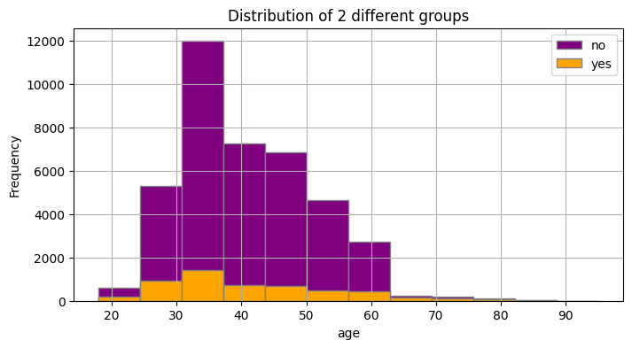

```python
df=bank_marketing[["age","y"]]
colors = ['purple', 'orange']
group_name = df['y'].unique()
for i, group in enumerate(group_name):
    ax = df[df['y']==group]['age'].hist(figsize=(8, 4),
                                        edgecolor='gray',
                                        bins=12,
                                        color=colors[i]
                                       )

# Add a legend
ax.legend(group_name)

# Add a title and axis label
ax.set_title('Distribution of 2 different groups')
ax.set_xlabel('age')
ax.set_ylabel('Frequency')

# Show the plot
plt.show()
```

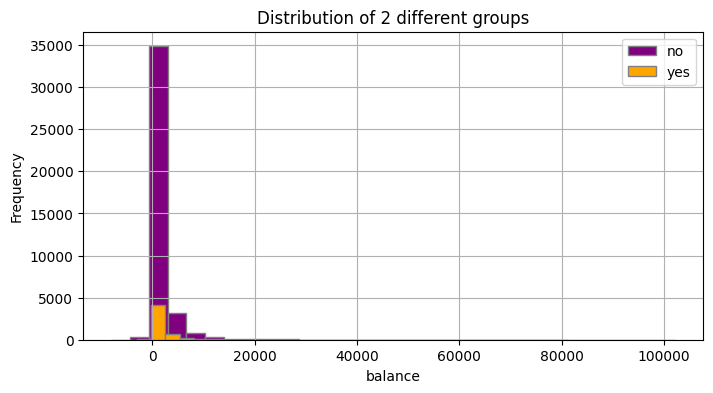

```python
df=bank_marketing[["balance","y"]]
colors = ['purple', 'orange']
group_name = df['y'].unique()
for i, group in enumerate(group_name):
    ax = df[df['y']==group]['balance'].hist(figsize=(8, 4),
                                        edgecolor='gray',
                                        bins=30,
                                        color=colors[i]
                                       )

# Add a legend
ax.legend(group_name)

# Add a title and axis label
ax.set_title('Distribution of 2 different groups')
ax.set_xlabel('balance')
ax.set_ylabel('Frequency')

# Show the plot
plt.show()
```

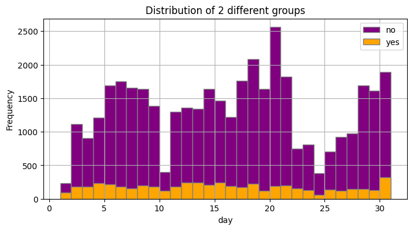

```python
df=bank_marketing[["day","y"]]
colors = ['purple', 'orange']
group_name = df['y'].unique()
for i, group in enumerate(group_name):
    ax = df[df['y']==group]['day'].hist(figsize=(8, 4),
                                        edgecolor='gray',
                                        bins=30,
                                        color=colors[i]
                                       )

# Add a legend
ax.legend(group_name)

# Add a title and axis label
ax.set_title('Distribution of 2 different groups')
ax.set_xlabel('day')
ax.set_ylabel('Frequency')

# Show the plot
plt.show()
```

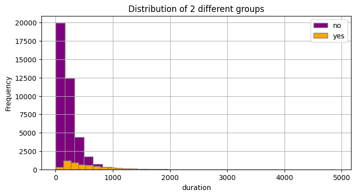

```python
df=bank_marketing[["duration","y"]]
colors = ['purple', 'orange']
group_name = df['y'].unique()
for i, group in enumerate(group_name):
    ax = df[df['y']==group]['duration'].hist(figsize=(8, 4),
                                        edgecolor='gray',
                                        bins=30,
                                        color=colors[i]
                                       )

# Add a legend
ax.legend(group_name)

# Add a title and axis label
ax.set_title('Distribution of 2 different groups')
ax.set_xlabel('duration')
ax.set_ylabel('Frequency')

# Show the plot
plt.show()
```

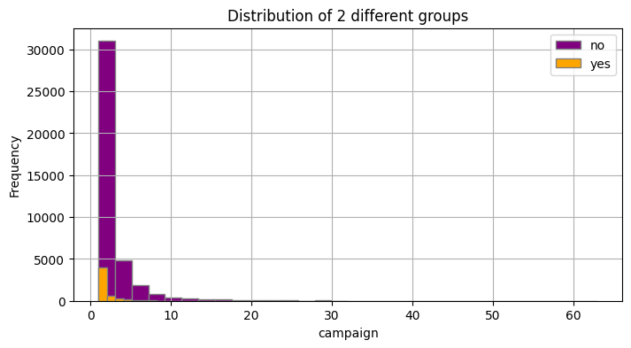

```python
df=bank_marketing[["campaign","y"]]
colors = ['purple', 'orange']
group_name = df['y'].unique()
for i, group in enumerate(group_name):
    ax = df[df['y']==group]['campaign'].hist(figsize=(8, 4),
                                        edgecolor='gray',
                                        bins=30,
                                        color=colors[i]
                                       )

# Add a legend
ax.legend(group_name)

# Add a title and axis label
ax.set_title('Distribution of 2 different groups')
ax.set_xlabel('campaign')
ax.set_ylabel('Frequency')

# Show the plot
plt.show()
```

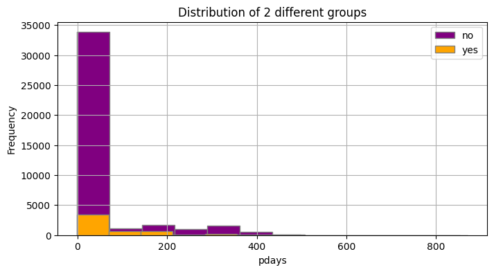

```python
df=bank_marketing[["pdays","y"]]
colors = ['purple', 'orange']
group_name = df['y'].unique()
for i, group in enumerate(group_name):
    ax = df[df['y']==group]['pdays'].hist(figsize=(8, 4),
                                        edgecolor='gray',
                                        bins=12,
                                        color=colors[i]
                                       )

# Add a legend
ax.legend(group_name)

# Add a title and axis label
ax.set_title('Distribution of 2 different groups')
ax.set_xlabel('pdays')
ax.set_ylabel('Frequency')

# Show the plot
plt.show()
```

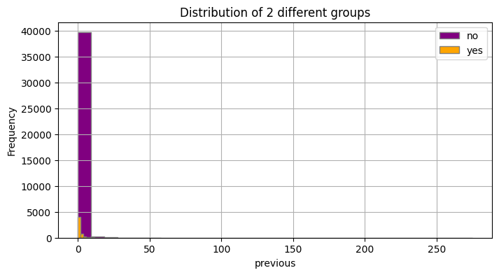

```python
df=bank_marketing[["previous","y"]]
colors = ['purple', 'orange']
group_name = df['y'].unique()
for i, group in enumerate(group_name):
    ax = df[df['y']==group]['previous'].hist(figsize=(8, 4),
                                        edgecolor='gray',
                                        bins=30,
                                        color=colors[i]
                                       )

# Add a legend
ax.legend(group_name)

# Add a title and axis label
ax.set_title('Distribution of 2 different groups')
ax.set_xlabel('previous')
ax.set_ylabel('Frequency')

# Show the plot
plt.show()
```

**Anàlisi:**  
Mirant els gràfics de barres i els histogrames, quins atributs semblen tenir més pes al moment de predir si es contractarà un dipòsit a termini o no? Creus que amb aquests atributs serà suficient per poder determinar si es contractarà o no el dipòsit?

Sembla que convèncer en posteriors contactes és molt més probable que en el primer, per tant, intentar aconseguir un segon contacte serà positiu.

No crec que puguis dir de ciència certa si el contractaran o no, però pots trobar quin és el client potencial i encarar millor la pròxima campanya de màrqueting.

**Exercici:** calculeu i mostreu la correlació entre les variables numèriques.

```python
bank_marketing[["age","balance","day","duration","campaign","pdays","previous"]].corr()
```

|  | age | balance | day | duration | campaign | pdays | previous |
| --- | --- | --- | --- | --- | --- | --- | --- |
| age | 1.000000 | 0.097783 | -0.009120 | -0.004648 | 0.004760 | -0.023758 | 0.001288 |
| balance | 0.097783 | 1.000000 | 0.004503 | 0.021560 | -0.014578 | 0.003435 | 0.016674 |
| day | -0.009120 | 0.004503 | 1.000000 | -0.030206 | 0.162490 | -0.093044 | -0.051710 |
| duration | -0.004648 | 0.021560 | -0.030206 | 1.000000 | -0.084570 | -0.001565 | 0.001203 |
| campaign | 0.004760 | -0.014578 | 0.162490 | -0.084570 | 1.000000 | -0.088628 | -0.032855 |
| pdays | -0.023758 | 0.003435 | -0.093044 | -0.001565 | -0.088628 | 1.000000 | 0.454820 |
| previous | 0.001288 | 0.016674 | -0.051710 | 0.001203 | -0.032855 | 0.454820 | 1.000000 |

**Anàlisi:** comenta els resultats.

pdays i previus estan bastant correlacionats perquè tots dos marquen contactes anteriors, un quan va ser l'últim contacte i l'altre quants contactes previs hi ha hagut, per tant, és normal que tinguin una correlació alta perquè quan no hi ha hagut contacte previ tots dos donen la mateixa informació, de la resta que passen del pvaule que normalment s'utilitza que és el 5% que em sembli que tenen sentit seria l'edat i el balanç que té sentit, ja que és més probable que tinguis més diners si ets més gran. day té correlacions amb diferents variables, però en ser day una variable bastant aleatòria no crec que sigui res més que una casualitat estadística, però sembla que hi ha una correlació, potser s'hauria de mirar a què és degut això.

# Preprocessament de les dades (1.5 punts)

Un cop analitzats els atributs descriptius, és el moment de preparar-los perquè ens siguin útils amb vista a predir valors.

A partir d’aquest punt, per simplicitat, treballarem únicament amb els atributs numèrics.

En aquest apartat:

Estandarditzarem (o normalitzarem) els valors dels atributs descriptius numèrics perquè les seves escales no siguin molt diferents.

Separarem el conjunt de dades original en dos subconjunts: entrenament i test.

**Pregunta:** quina tècnica podríem fer servir per codificar els atributs categòrics de format numèric?

Utilitzar funcions com get_dummies() per posar 0 si no estan a una classe o 1 si estan i el nom de la variable pasa a ser aquesta clase, exemple si tindriem una columa unemployed que seria 1 si es unemployed i 0 si no ho es i aixi amb totes les caracteristiques

**Exercici:** conserva els atributs descriptius numèrics i estandarditza’ls, aquest serà el nou conjunt d’atributs descriptius amb el qual treballarem a partir d’ara.

Suggeriment: utilitzeu "StandardScaler" de *preprocessing*.

```python
X=bank_marketing[["age","balance","day","duration","campaign","pdays","previous"]]
from sklearn.preprocessing import StandardScaler
object= StandardScaler()
X = object.fit_transform(X)
y=bank_marketing["y"]
```

**Exercici:** separa els atributs descriptius escalats i la variable objectiu en els subconjunts d’entrenament i de prova.

Suggeriment: per separar entre entrenament i prova podeu utilitzar "train_test_split" de sklearn.

```python
X_train, X_test, y_train, y_test = train_test_split(
    X, y, test_size=0.33, random_state=42)
```

**Anàlisi:** valora si la decisió de transformar el conjunt de dades (estandardització) abans de realitzar la separació del conjunt de dades en els subconjunts d’entrenament i prova, és una bona idea.

No ho és, la millor idea seria fer l'estandardització després de separar guardar com hem estandarditzat (guardat la mitjana i la variància) per després normalitzar les dades de test utilitzant la variància i la mitjana anterior, ja que és com tractarem les noves entrades de dades que tindrem, per tant, comprovarem test en les mateixes característiques que les noves dades que tinguem.

**Anàlisi:** en aquest exercici hem estandarditzat els valors dels atributs descriptius perquè les seves escales no siguin molt diferents (unificar-les). Què ens aporta estandarditzar els atributs descriptius?, hi ha alguna situació o escenari on sigui imprescindible?

Si les escales són molt diferents pot ser que variables s'invisibilitzin, en el nostre exemple age té un ordre de desenes, en canvi, balance té un ordre de desenes de milers, per tant, si no normalitzem pot ser que balance tingui molt més pes que edat només per tindre un valor molt més gran, jo crec que en general si les escales de les dades són diferents, normalitzar o estandarditzar les dades ajudarà al fet que el model funcioni millor.